# R Intermediate Course 2026

## R is a Lego Construction Set – Package Dependencies

The base R function **`package_dependencies`** queries information on the CRAN repository. Therefore we **`need to set a valid CRAN mirror`**, if we have not already done so:

```r
options(repos = findCRANmirror("web"))
getOption("repos")
```

```
[1] "https://CRAN.R-project.org"
```

List the **`strong dependencies`** of the plotting package ggplot2, i.e. those packages which **`need to be installed for ggplot2 to work`**:

```r
tools::package_dependencies("ggplot2", which="strong")
```

```
$ggplot2
 [1] "cli"       "grDevices" "grid"      "gtable"    "isoband"   "lifecycle"
 [7] "rlang"     "S7"        "scales"    "stats"     "vctrs"     "withr"
```

## R is a Lego Construction Set – the CRAN repository

[figure not shown]

## R is a Lego Construction Set – the CRAN repository

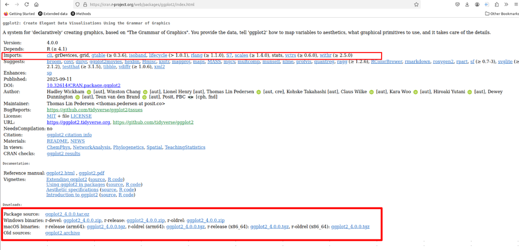

## R is a Lego Construction Set – Libraries

While repositories are package sources, a **`destination folder for packages on our local system`** is called a **`library`**.

There may be more than a single library folder.  
Function **`.libPaths()`** can be used **`to list them`** :

```r
.libPaths()
```

```
[1] "/home/ugoebel/R-4.4.3/lib/R/library"
```

## R is a Lego Construction Set – Install a Package (via R)

**`Bioi`** is a small and barebones package related to **`bioimaging`** . Let’s install it from CRAN:

```r
install.packages("Bioi",
                 lib = .libPaths()[1],
                 repos = getOption("repos")
                 )
```

Note that **`parameters "lib" and "repos" are superfluous in this case`**, because

- packages are by default installed to **`.libPaths()[1]`** (the user library)
- we have already set the CRAN mirror URL above.

## R is a Lego Construction Set – Install a Package (in rstudio)

First remove it again …

```r
remove.packages("Bioi")
```

**`Restart the R session for rstudio's Packages pane to realize the change`**!

## R is a Lego Construction Set – Install a Package (in rstudio)

Then do it rstudio-compliant:

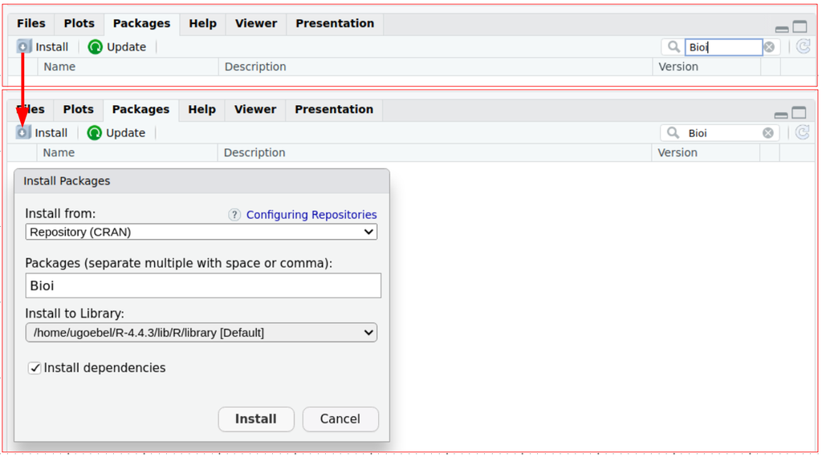

## R is a Lego Construction Set – Install a Package (in rstudio)

**`Have an eye on what happens in the console:`**

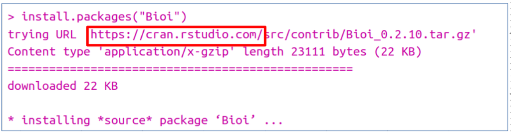

It uses a different CRAN mirror from the one we had set above!  
This happens because R had been restarted in between.

**`If you want a permanent value for an option,`**

**`set it in your .Rprofile file!`**

## R is a Lego Construction Set – Load a Package (in rstudio)

Checking an entry in the Packages list invokes the **`library()`** function:

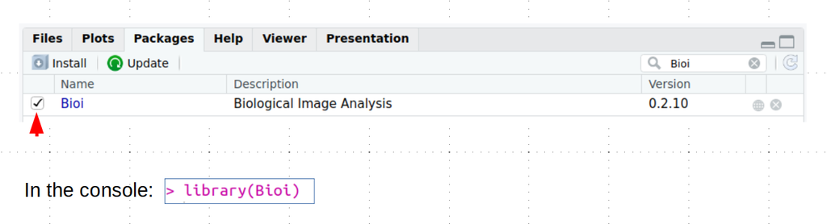

## R is a Lego Construction Set – Load a Package

**`library(PKG)`** without further arguments **`scans .libPath()`**.

The first entry found with name “PKG”

- is **`attached to the search path`**
- its **`namespace is loaded`**  
  (code can now refer to PKS’s functions by name, without specifying the package)

A shortcut to **access one of PKG’s functions without library(PKG)** is this:  
**`PKG::function_I_want_to_run()`**.

PKG would then be in the state **`loaded via namespace (and not attached)`**.

## R is a Lego Construction Set – Package Dependencies

Package **A** may “depend” on another package **B** because

- **A uses a functionality of B in its core computations.** Whenever A is installed, B is automatically also installed, and if installation of B fails, then the installation of A fails, too.  
  This scenario comes in **two flavors**:
  - A **`"Imports:"`** B: A loads B’s functions via namespace
  - A **`"Depends:"`** on B: A attaches B to the search path
- **A can optionally use a functionality of B, in case B is available**  
  This **`"Suggests:"`** dependency allows A to be installed even if B cannot.

**Dependencies are declared in the** **`DESCRIPTION and NAMESPACE files`** of a package.  
(They should be readable in the package’s sub-folder of your library folder).

## R is a Lego Construction Set – Package Dependencies

The `risk of installation failure` which comes with an **Imports:** or **Depends:** directive is `not immediately obvious from the DESCRIPTION file`!

Assume Package **P** depends on or imports four packages **A**, **B**, **P1**, and **P2**.

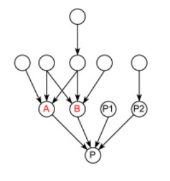

**`P's dependencies on A and B are much more risky`**  
**`than those on P1 and P2`**:

- A and B have **more total (direct and indirect) dependencies** than P1 and P2
- A and B **share dependencies**: both will fail if one of these fails

https://www.sciencedirect.com/science/article/pii/S0164121223000055

## R is a Lego Construction Set – Package Dependencies

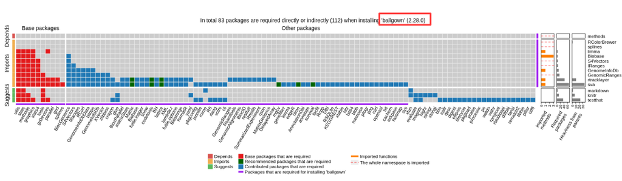

The **ballgown package** provides tools for statistical analysis of assembled transcriptomes, including flexible differential expression analysis, visualization of transcript structures, and matching of assembled transcripts to annotation.

## R is a Lego Construction Set – Package Dependencies

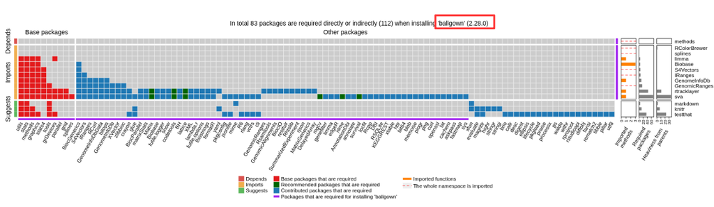

[follow this link to create a dependency plot for a Bioconductor package](https://pkgndep.github.io/)

## R is a Lego Construction Set – Package Ecosystems

The [**`easystats`**](https://easystats.github.io/easystats/) package orchestrates a small set of dependent packages,

- with the mission  
  “to provide a unifying and consistent framework to tame, discipline, and harness the scary R statistics and their pesky model”
- with [a common GitHub page](https://github.com/easystats)
- with [common documentation on github.io](https://easystats.github.io/easystats/)

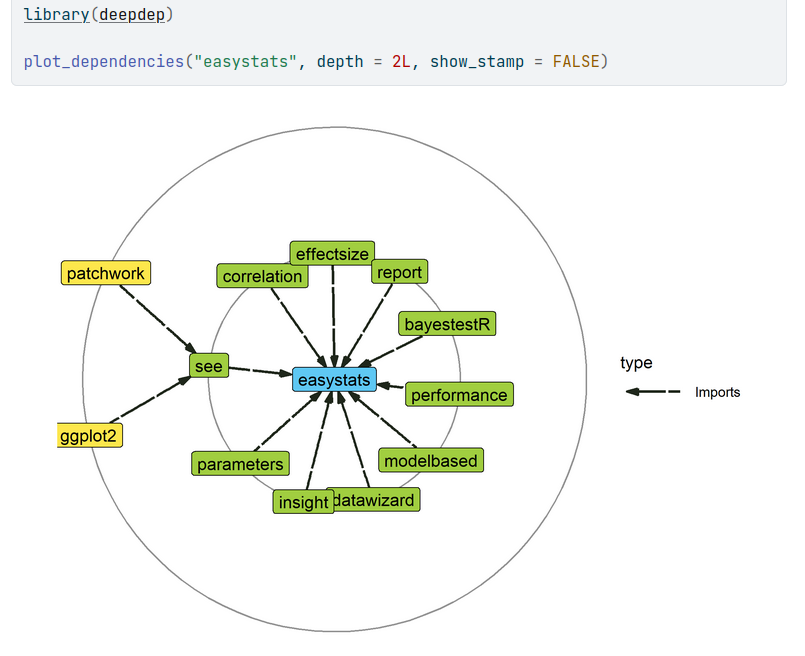

An exemplary example of a **`package ecosystem`** in a nutshell!

## R is a Lego Construction Set – Package Ecosystems

Going Large: [Bioconductor](https://www.bioconductor.org/)

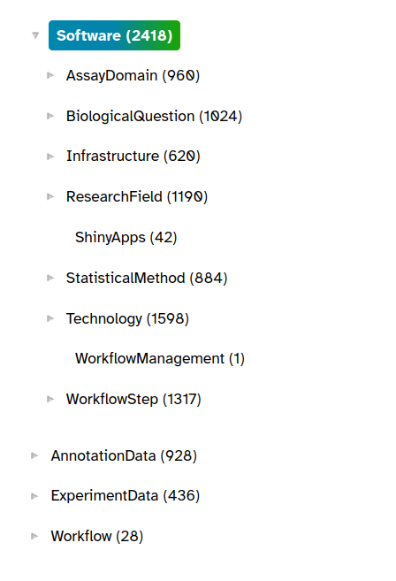

[figure not shown]

## R is a Lego Construction Set – Bioconductor

Bioconductor has its **`own repository and installer`**,

- because the R and Bioconductor release schedules do not match
- and the package interdependencies require version compatibility

```r
## if not installed, install via install.packages()
if (!require("BiocManager", quietly = TRUE))
    install.packages("BiocManager")

## once installed, use it to install an entire Bioconductor version (here)  or individual packages
BiocManager::install(version=3.21)
```

## R is a Lego Construction Set – Bioconductor

[The official Bioconductor website](https://www.bioconductor.org/) is very comprehensive, but can be overwhelming!

[This site](https://carpentries-incubator.github.io/bioc-project/02-introduction-to-bioconductor.html) provides a more gentle, but still comprehensive walk-through.

Bioconductor also provides **`workflow packages`**, e.g. the `rnaseqGene` workflow.  
Let’s look at its documentation.

```r
# Don't actually install it now -- it co-installs half of Bioconductor!
BiocManager::install("rnaseqGene")
```

```r
browseVignettes("rnaseqGene")
```

## R is a Lego Construction Set – Bioconductor

[interactive chart not shown]

## R is a Lego Construction Set – The Tidyverse

And then there is the **`Tidyverse`**, a large and growing ecosystem of cross-compatible packages, with focus on workflows on 2D tables and graphical objects:

[figure not shown]

[figure not shown]